# Basic Text Mining with R

In this lab we will demonstrate the basic steps of using R to build a predictive model for movie review sentiments. Source of the data is from http://www.cs.cornell.edu/people/pabo/movie-review-data/.

# Import data and representation

First install and load packages needed for text mining.

```r
install.packages(c('tm', 'SnowballC', 'wordcloud', 'topicmodels'))
```

```r
library(tm)
```

```r
library(SnowballC)
library(wordcloud)
```

Next we load the move review dataset

```r
reviews = read.csv("movie_reviews.csv", stringsAsFactors = F, row.names = 1)
```

The review dataset has two variables: *content* of the review, and *polarity* of the review (0 or 1). To use the *tm* package we first transfrom the dataset to a corpus:

```r
review_corpus = Corpus(VectorSource(reviews$content))
```

Next we normalize the texts in the reviews using a series of pre-processing steps: 1. Switch to lower case 2. Remove numbers 3. Remove punctuation marks and stopwords 4. Remove extra whitespaces

```r
review_corpus = tm_map(review_corpus, content_transformer(tolower))
review_corpus = tm_map(review_corpus, removeNumbers)
review_corpus = tm_map(review_corpus, removePunctuation)
review_corpus = tm_map(review_corpus, removeWords, c("the", "and", stopwords("english")))
review_corpus =  tm_map(review_corpus, stripWhitespace)
```

After the above transformations the first review looks like

```r
inspect(review_corpus[1])
```

```
## <<VCorpus>>
## Metadata:  corpus specific: 0, document level (indexed): 0
## Content:  documents: 1
##
## [[1]]
## <<PlainTextDocument>>
## Metadata:  7
## Content:  chars: 2269
```

To analyze the textual data, we use a Document-Term Matrix (DTM) representation: documents as the rows, terms/words as the columns, frequency of the term in the document as the entries. Because the number of unique words in the corpus the dimension can be large.

```r
review_dtm <- DocumentTermMatrix(review_corpus)
review_dtm
```

```
## <<DocumentTermMatrix (documents: 2000, terms: 46460)>>
## Non-/sparse entries: 538003/92381997
## Sparsity           : 99%
## Maximal term length: 61
## Weighting          : term frequency (tf)
```

```r
inspect(review_dtm[500:505, 500:505])
```

```
## <<DocumentTermMatrix (documents: 6, terms: 6)>>
## Non-/sparse entries: 0/36
## Sparsity           : 100%
## Maximal term length: 11
## Weighting          : term frequency (tf)
##
##      Terms
## Docs  adolescents adolf adolph adopt adopted adopter
##   500           0     0      0     0       0       0
##   501           0     0      0     0       0       0
##   502           0     0      0     0       0       0
##   503           0     0      0     0       0       0
##   504           0     0      0     0       0       0
##   505           0     0      0     0       0       0
```

```r
review_dtm = removeSparseTerms(review_dtm, 0.99)
review_dtm
```

```
## <<DocumentTermMatrix (documents: 2000, terms: 4366)>>
## Non-/sparse entries: 400173/8331827
## Sparsity           : 95%
## Maximal term length: 17
## Weighting          : term frequency (tf)
```

The first review now looks like

```r
inspect(review_dtm[1,1:20])
```

```
## <<DocumentTermMatrix (documents: 1, terms: 20)>>
## Non-/sparse entries: 1/19
## Sparsity           : 95%
## Maximal term length: 12
## Weighting          : term frequency (tf)
##
##     Terms
## Docs abandon abandoned abilities ability able aboard absence absent
##    1       0         0         0       0    0      0       0      0
##     Terms
## Docs absolute absolutely absurd abuse abyss academy accent accept
##    1        0          0      0     0     0       0      0      0
##     Terms
## Docs acceptable accepts accident accidentally
##    1          0       0        1            0
```

We can draw a simple word cloud

```r
findFreqTerms(review_dtm, 1000)
```

```
##  [1] "action"     "also"       "another"    "back"       "bad"
##  [6] "best"       "can"        "character"  "characters" "director"
## [11] "doesnt"     "dont"       "end"        "even"       "film"
## [16] "films"      "first"      "get"        "good"       "great"
## [21] "hes"        "just"       "know"       "life"       "like"
## [26] "little"     "love"       "made"       "make"       "man"
## [31] "many"       "movie"      "movies"     "much"       "never"
## [36] "new"        "one"        "people"     "plot"       "really"
## [41] "scene"      "scenes"     "see"        "seems"      "something"
## [46] "still"      "story"      "time"       "two"        "way"
## [51] "well"       "will"       "work"
```

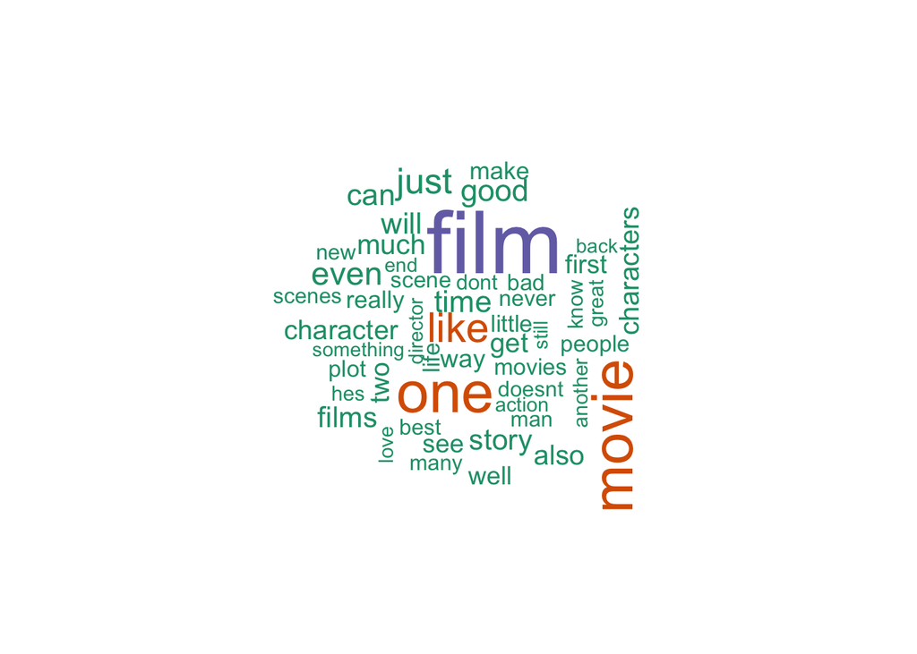

```r
freq = data.frame(sort(colSums(as.matrix(review_dtm)), decreasing=TRUE))
wordcloud(rownames(freq), freq[,1], max.words=50, colors=brewer.pal(1, "Dark2"))
```

One may argue that in the wordcloud, words such as *one*, *film*, *movie* do not carry too much meaning in the setting, since we know that the entire corpus is about movies. Therefore sometimes it is necessary to use the [tf–idf(term frequency–inverse document frequency)](https://en.wikipedia.org/wiki/Tf%E2%80%93idf) instead of the frequencies of the term as entries, tf-idf measures the relative importance of a word to a document.

```r
review_dtm_tfidf <- DocumentTermMatrix(review_corpus, control = list(weighting = weightTfIdf))
review_dtm_tfidf = removeSparseTerms(review_dtm_tfidf, 0.95)
review_dtm_tfidf
```

```
## <<DocumentTermMatrix (documents: 2000, terms: 963)>>
## Non-/sparse entries: 254264/1671736
## Sparsity           : 87%
## Maximal term length: 14
## Weighting          : term frequency - inverse document frequency (normalized) (tf-idf)
```

```r
# The first document
inspect(review_dtm_tfidf[1,1:20])
```

```
## <<DocumentTermMatrix (documents: 1, terms: 20)>>
## Non-/sparse entries: 3/17
## Sparsity           : 85%
## Maximal term length: 10
## Weighting          : term frequency - inverse document frequency (normalized) (tf-idf)
##
##     Terms
## Docs ability able absolutely across act acting action actor      actors
##    1       0    0          0      0   0      0      0     0 0.005821345
##     Terms
## Docs actress actual   actually add admit age agent        ago air alien
##    1       0      0 0.01088143   0     0   0     0 0.01054396   0     0
##     Terms
## Docs alive
##    1     0
```

Is the new word cloud more informative?

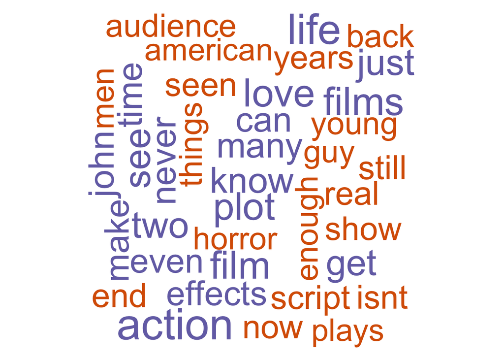

```r
freq = data.frame(sort(colSums(as.matrix(review_dtm_tfidf)), decreasing=TRUE))
wordcloud(rownames(freq), freq[,1], max.words=100, colors=brewer.pal(1, "Dark2"))
```

## Predictive modeling

To predict the polarity (sentiment) of a review, we can make use of a precompiled list of words with positive and negative meanings ([Source](http://www.cs.uic.edu/~liub/FBS/sentiment-analysis.html)

```r
neg_words = read.table("negative-words.txt", header = F, stringsAsFactors = F)[, 1]
pos_words = read.table("positive-words.txt", header = F, stringsAsFactors = F)[, 1]
```

As simple indicators, we create two variables (neg, pos) that contain the number of positive and negative words in each document

```r
reviews$neg = sapply(review_corpus, tm_term_score, neg_words)
reviews$pos = sapply(review_corpus, tm_term_score, pos_words)
```

Let’s remove the actual texual content for statistical model building

```r
reviews$content = NULL
```

Now we can combine the tf-idf matrix with the sentiment polarity according to the sentiment lists.

```r
reviews = cbind(reviews, as.matrix(review_dtm_tfidf))
reviews$polarity = as.factor(reviews$polarity)
```

Split to testing and training set

```r
id_train <- sample(nrow(reviews),nrow(reviews)*0.80)
reviews.train = reviews[id_train,]
reviews.test = reviews[-id_train,]
```

The rest should be natural for you by this point. We can compare the performance of logistic regression, decision tree, SVM, and neural network models.

```r
install.packages(c('rpart', 'rpart.plot', 'e1071', 'nnet'))
```

```r
library(rpart)
library(rpart.plot)
library(e1071)
library(nnet)
```

Train models:

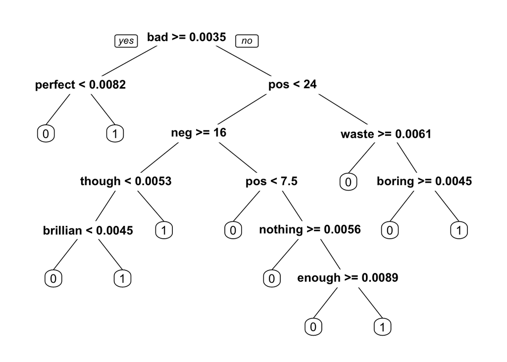

```r
reviews.tree = rpart(polarity~.,  method = "class", data = reviews.train);
prp(reviews.tree)
```

```r
reviews.glm = glm(polarity~ ., family = "binomial", data =reviews.train, maxit = 100);
reviews.svm = svm(polarity~., data = reviews.train);
reviews.nnet = nnet(polarity~., data=reviews.train, size=1, maxit=500)
```

Evaluate performance with the test set:

```r
pred.tree = predict(reviews.tree, reviews.test,  type="class")
table(reviews.test$polarity,pred.tree,dnn=c("Obs","Pred"))
```

```
##    Pred
## Obs   0   1
##   0 136  63
##   1  64 137
```

```r
mean(ifelse(reviews.test$polarity != pred.tree, 1, 0))
```

```
## [1] 0.3175
```

```r
pred.glm = as.numeric(predict(reviews.glm, reviews.test, type="response") > 0.5)
table(reviews.test$polarity,pred.glm,dnn=c("Obs","Pred"))
```

```
##    Pred
## Obs   0   1
##   0 141  58
##   1  61 140
```

```r
mean(ifelse(reviews.test$polarity != pred.glm, 1, 0))
```

```
## [1] 0.2975
```

```r
pred.svm = predict(reviews.svm, reviews.test)
table(reviews.test$polarity,pred.svm,dnn=c("Obs","Pred"))
```

```
##    Pred
## Obs   0   1
##   0 170  29
##   1  41 160
```

```r
mean(ifelse(reviews.test$polarity != pred.svm, 1, 0))
```

```
## [1] 0.175
```

```r
prob.nnet= predict(reviews.nnet,reviews.test)
pred.nnet = as.numeric(prob.nnet > 0.5)
table(reviews.test$polarity, pred.nnet, dnn=c("Obs","Pred"))
```

```
##    Pred
## Obs   0   1
##   0 162  37
##   1  41 160
```

```r
mean(ifelse(reviews.test$polarity != pred.nnet, 1, 0))
```

```
## [1] 0.195
```